# Creating R Packages: A Tutorial

Sam Gabor

3/8/2021

## 1.0 Overview

Creating custom R packages allows users to exchange code logic and data effortlessly. In addition, even if R packages are not shared with others, they still provide utility for the R user because they group related functionality into clean, easily maintained and tested units.

This tutorial will illustrate the creation of a non-trivial R package covering all the steps that constitute a good work flow. It culminates in publishing the created package on GitHub where it can be shared with other users.

## 2.0 Motivation

The first step in creating an R package is deciding what functionality and/or data will be packaged as a unit. For this tutorial, I chose to package access to the CDC’s “Provisional COVID-19 Death Counts by Sex, Age, and State” data set (see: https://dev.socrata.com/foundry/data.cdc.gov/9bhg-hcku). The CDC provides this periodically updated data set through download and a REST API. The site does not require an API key so it’s easy to work with for illustrative purposes.

Of course, for a bulk, one-time analysis of the data, the file download may be adequate, but for multiple analysis over time, it’s better to have an easier way to fetch cleaned data that can also be filtered by content (instead of downloading the whole data set and then filtering and cleaning).

Thus, the R package in this tutorial, dubbed PCD, will do the following:

1. Fetch the latest dataset, optionally filtered by State
2. Allow the user to specify the maximum number of records returned
3. Clean the fetched data (by converting strings to proper values, such as dates, integers, etc.)

The end result is that the package user will be able to start working with the latest data immediately for charts and analysis without having to worry about downloading or preparing the data.

## 3.0 Prerequisites

To create R packages, you should install the latest version of R and RStudio then the following packages in your environment:

```r
install.packages(c("devtools", "roxygen2", "testthat", "knitr"))
```

In addition, you should download and install the R build toolchain from: https://cran.r-project.org/bin/windows/Rtools/. This may not be needed until you build packages in C/C++, but if it’s not installed you will always see a warning during package builds (as you’ll see in this tutorial).

## 4.0 Creating Initial Package

Once all the pre-requisites are installed, launch RStudio and run the following command:

```r
library(devtools)
create_package("~/PCD")
```

Expect to see output similar to the below

```r
√ Creating 'C:/Users/samga/PCD/'
√ Setting active project to 'C:/Users/samga/PCD'
√ Creating 'R/'
√ Writing 'DESCRIPTION'
Package: PCD
Title: What the Package Does (One Line, Title Case)
Version: 0.0.0.9000
Authors@R (parsed):
    * First Last <first.last@example.com> [aut, cre] (YOUR-ORCID-ID)
Description: What the package does (one paragraph).
License: `use_mit_license()`, `use_gpl3_license()` or friends to
    pick a license
Encoding: UTF-8
LazyData: true
Roxygen: list(markdown = TRUE)
RoxygenNote: 7.1.1
√ Writing 'NAMESPACE'
√ Writing 'PCD.Rproj'
√ Adding '^PCD\\.Rproj$' to '.Rbuildignore'
√ Adding '.Rproj.user' to '.gitignore'
√ Adding '^\\.Rproj\\.user$' to '.Rbuildignore'
√ Opening 'C:/Users/samga/PCD/' in new RStudio session
√ Setting active project to '<no active project>'
```

This will initialize a new package folder called PCD in your home directory and launch a new instance of RStudio. Your display should be similar to the below.

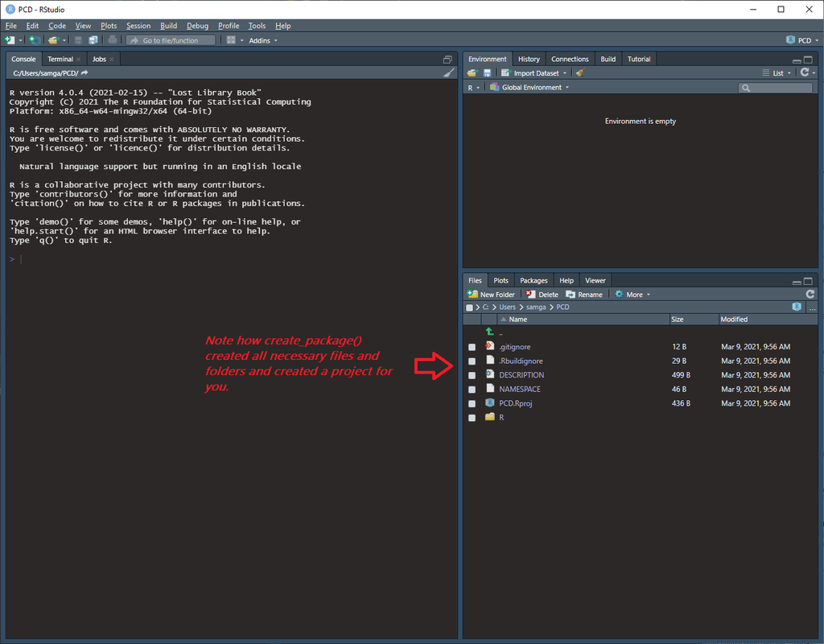

RStudio session (after create_package() call)